# Data visualisation, mean separation & Continuous data - TRR259 seminar Session 1

### scales

scales is a [R package](https://scales.r-lib.org/) for the handling of scales and labels of scales. You might want to explore it for specific needs, but below we use it to specify the labels on a bar plot with the “fill” option, so the the y axis shows percentage labels:

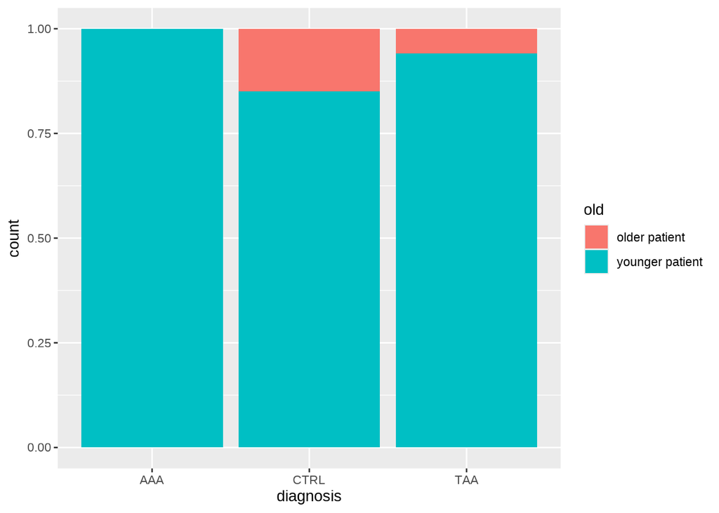

```r
df_plot <- df_sub %>%
  filter(bmi > 20) %>%
  mutate(old = ifelse(age > 75, "older patient", "younger patient"))

df_plot%>%
  ggplot(aes(diagnosis, fill = old))+
  geom_bar(position = "fill")
```

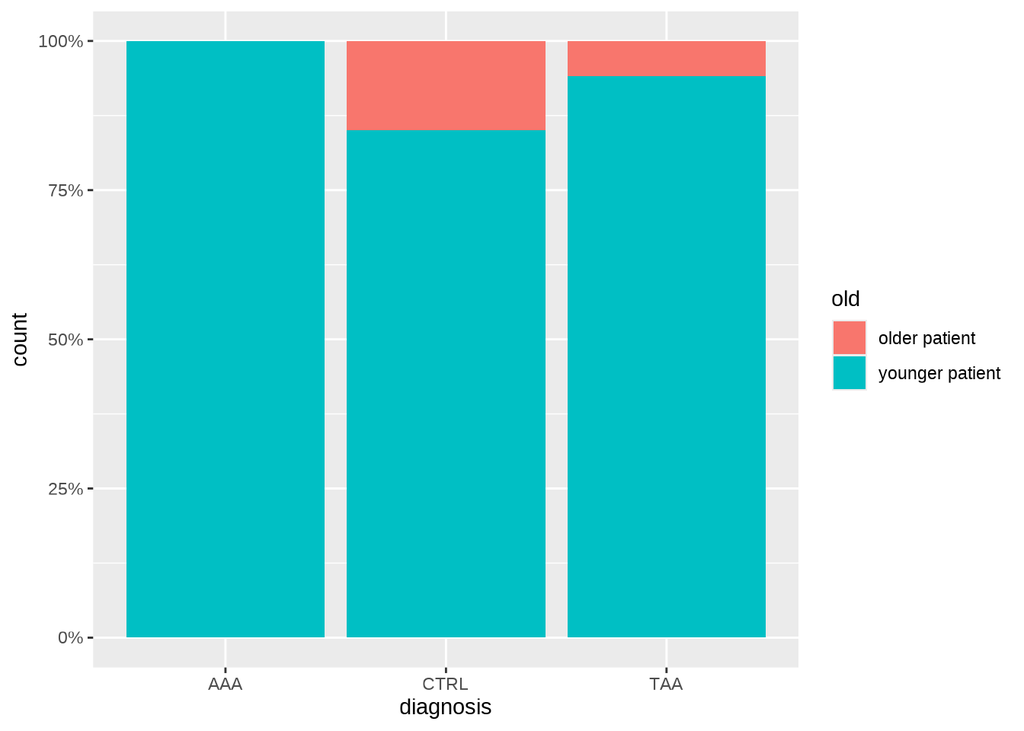

```r
df_plot%>%
  ggplot(aes(diagnosis, fill = old))+
  geom_bar(position = "fill")+
  scale_y_continuous(labels = scales::label_percent())
```

### theme_x() - prebuilt themes

The default background of a ggplot is grey, with white grid lines. There is a range of [pre-built themes](https://ggplot2.tidyverse.org/reference/ggtheme.html), that you can add on to your plots. Below is a selection, but some googling goes a long way.

[output not shown]

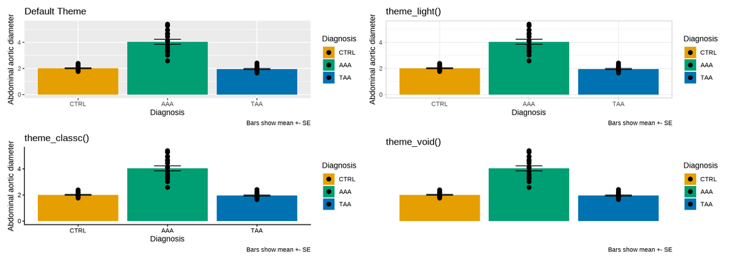

```r
p1 <- df_sub %>%
  mutate(diagnosis = fct_relevel(diagnosis, "CTRL")) %>%
  ggplot(aes(diagnosis, abdominal_diameter, fill = diagnosis))+
  stat_summary(geom = "bar")+
  stat_summary(geom = "errorbar", width = 0.3)+
  geom_point(size = 2.5)+
  labs(x = "Diagnosis", y = "Abdominal aortic diameter",
       title = "Default Theme",
       caption = "Bars show mean +- SE",
       fill = "Diagnosis")+
  scale_fill_manual(values = thematic::okabe_ito(3))

p2 <- df_sub %>%
  mutate(diagnosis = fct_relevel(diagnosis, "CTRL")) %>%
  ggplot(aes(diagnosis, abdominal_diameter, fill = diagnosis))+
  stat_summary(geom = "bar")+
  stat_summary(geom = "errorbar", width = 0.3)+
  geom_point(size = 2.5)+
  labs(x = "Diagnosis", y = "Abdominal aortic diameter",
       title = "theme_light()",
       caption = "Bars show mean +- SE",
       fill = "Diagnosis")+
  scale_fill_manual(values = thematic::okabe_ito(3))+
  theme_light()

p3 <- df_sub %>%
  mutate(diagnosis = fct_relevel(diagnosis, "CTRL")) %>%
  ggplot(aes(diagnosis, abdominal_diameter, fill = diagnosis))+
  stat_summary(geom = "bar")+
  stat_summary(geom = "errorbar", width = 0.3)+
  geom_point(size = 2.5)+
  labs(x = "Diagnosis", y = "Abdominal aortic diameter",
       title = "theme_classc()",
       caption = "Bars show mean +- SE",
       fill = "Diagnosis")+
  scale_fill_manual(values = thematic::okabe_ito(3))+
  theme_classic()


p4 <- df_sub %>%
  mutate(diagnosis = fct_relevel(diagnosis, "CTRL")) %>%
  ggplot(aes(diagnosis, abdominal_diameter, fill = diagnosis))+
  stat_summary(geom = "bar")+
  stat_summary(geom = "errorbar", width = 0.3)+
  geom_point(size = 2.5)+
  labs(x = "Diagnosis", y = "Abdominal aortic diameter",
       title = "theme_void()",
       caption = "Bars show mean +- SE",
       fill = "Diagnosis")+
  scale_fill_manual(values = thematic::okabe_ito(3))+
  theme_void()

patchwork::wrap_plots(list(p1,p2,p3,p4))
```

# forcats

A lot of the aspects of plotting with ggplot happen below the surface, where a lot of the complexity is hidden. One of these things that you do need to interact with are factors and factor levels. A lot of variables are converted to factors and then these factor levels are used to infer order. We need to be able to make changes to this system and luckily, there is a [package](https://forcats.tidyverse.org/) for this, forcats. We will be using mostly `fct_relevel()` and `fct_reorder()`, but a wide variety exists.

## fct_relevel()

If we’re building a boxplot like below with the categorical variable diagnosis on the x axis, by default, it is alphabetically ordered. While not technically wrong, we do not want this. Instead, we would want the CTRL level to be the first level.

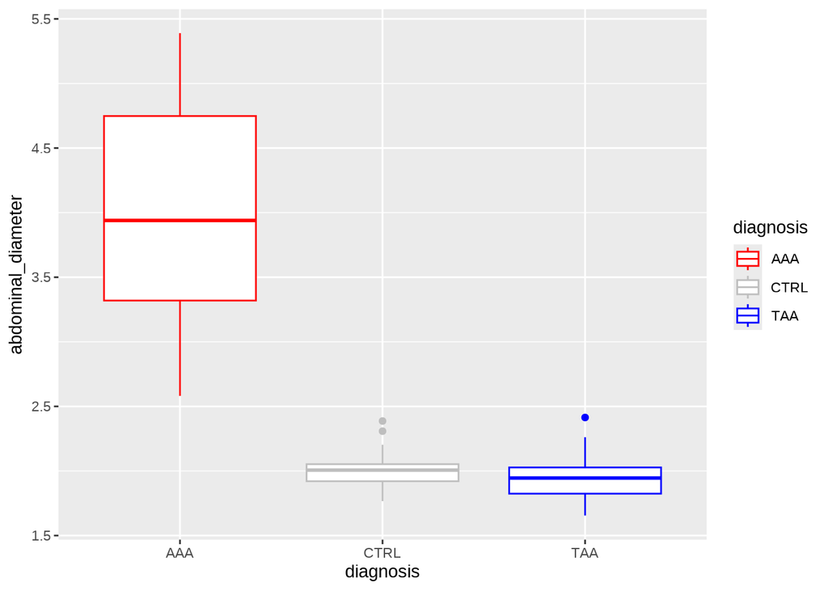

```r
df_sub %>%
  ggplot(aes(diagnosis, abdominal_diameter, color = diagnosis))+
  geom_boxplot()+
  scale_color_manual(values = c("red", "grey", "blue"))
```

For this, we can use `fct_relevel()`. Together with `mutate()`, we overwrite the existing diagnosis variable, replacing it with a modified version, where we set CTRL to be the reference level. Note that the color code also changes, as it depends on the order of the factor levels!

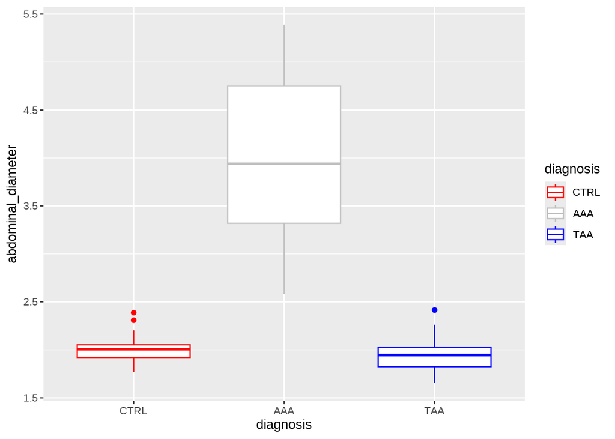

```r
df_sub %>%
  mutate(diagnosis = fct_relevel(diagnosis, "CTRL")) %>%
  ggplot(aes(diagnosis, abdominal_diameter, color = diagnosis))+
  geom_boxplot()+
  scale_color_manual(values = c("red", "grey", "blue"))
```

## fct_reorder()

Another way to set the levels is to use numerical values of different variables.

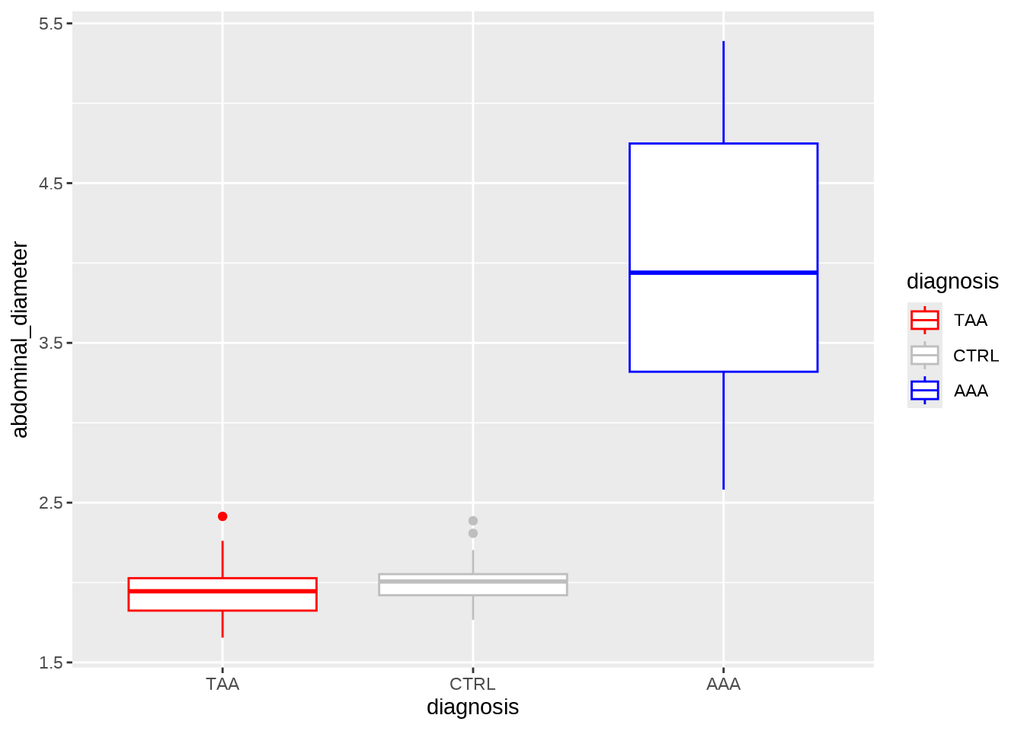

```r
df_sub %>%
  mutate(diagnosis = fct_reorder(diagnosis, abdominal_diameter)) %>%
  ggplot(aes(diagnosis, abdominal_diameter, color = diagnosis))+
  geom_boxplot()+
  scale_color_manual(values = c("red", "grey", "blue"))
```

# Mean separation

```r
library(rstatix)
df_sub %>%
  t_test(abdominal_diameter ~ diagnosis)
```

|  | .y. | group1 | group2 | n1 | n2 | statistic | df | p | p.adj | p.adj.signif |
| --- | --- | --- | --- | --- | --- | --- | --- | --- | --- | --- |
| 1 | abdominal_diameter | AAA | CTRL | 20 | 20 | 10.448948 | 20.35705 | 1.25e-09 | 2.50e-09 | **** |
| 2 | abdominal_diameter | AAA | TAA | 20 | 20 | 10.673263 | 20.81678 | 6.74e-10 | 2.02e-09 | **** |
| 3 | abdominal_diameter | CTRL | TAA | 20 | 20 | 1.009025 | 37.21380 | 3.19e-01 | 3.19e-01 | ns |

```r
df_sub %>%
  group_by(hypertension) %>%
  t_test(abdominal_diameter ~ diagnosis)
```

|  | hypertension | .y. | group1 | group2 | n1 | n2 | statistic | df | p | p.adj | p.adj.signif |
| --- | --- | --- | --- | --- | --- | --- | --- | --- | --- | --- | --- |
| 1 | 0 | abdominal_diameter | AAA | CTRL | 10 | 10 | 8.7055007 | 9.333229 | 8.83e-06 | 1.77e-05 | **** |
| 2 | 0 | abdominal_diameter | AAA | TAA | 10 | 10 | 8.6463759 | 10.207335 | 5.16e-06 | 1.55e-05 | **** |
| 3 | 0 | abdominal_diameter | CTRL | TAA | 10 | 10 | 0.5021738 | 13.599829 | 6.24e-01 | 6.24e-01 | ns |
| 4 | 1 | abdominal_diameter | AAA | CTRL | 10 | 10 | 6.2883878 | 9.965409 | 9.18e-05 | 2.14e-04 | *** |
| 5 | 1 | abdominal_diameter | AAA | TAA | 10 | 10 | 6.5975960 | 9.671458 | 7.13e-05 | 2.14e-04 | *** |
| 6 | 1 | abdominal_diameter | CTRL | TAA | 10 | 10 | 0.8757762 | 17.433248 | 3.93e-01 | 3.93e-01 | ns |

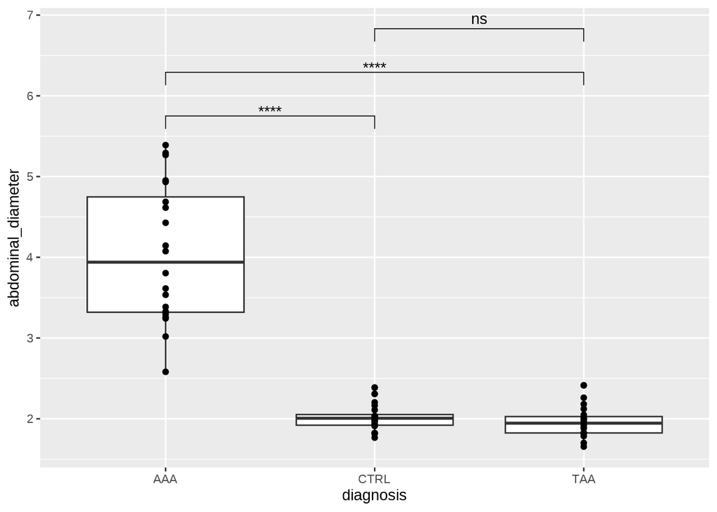

```r
stats <- df_sub %>%
  rstatix::t_test(abdominal_diameter ~ diagnosis) %>%
  add_xy_position()


df_sub %>%
  ggplot(aes(diagnosis, abdominal_diameter))+
  geom_boxplot()+
  geom_point()+
  ggpubr::stat_pvalue_manual(stats)
```

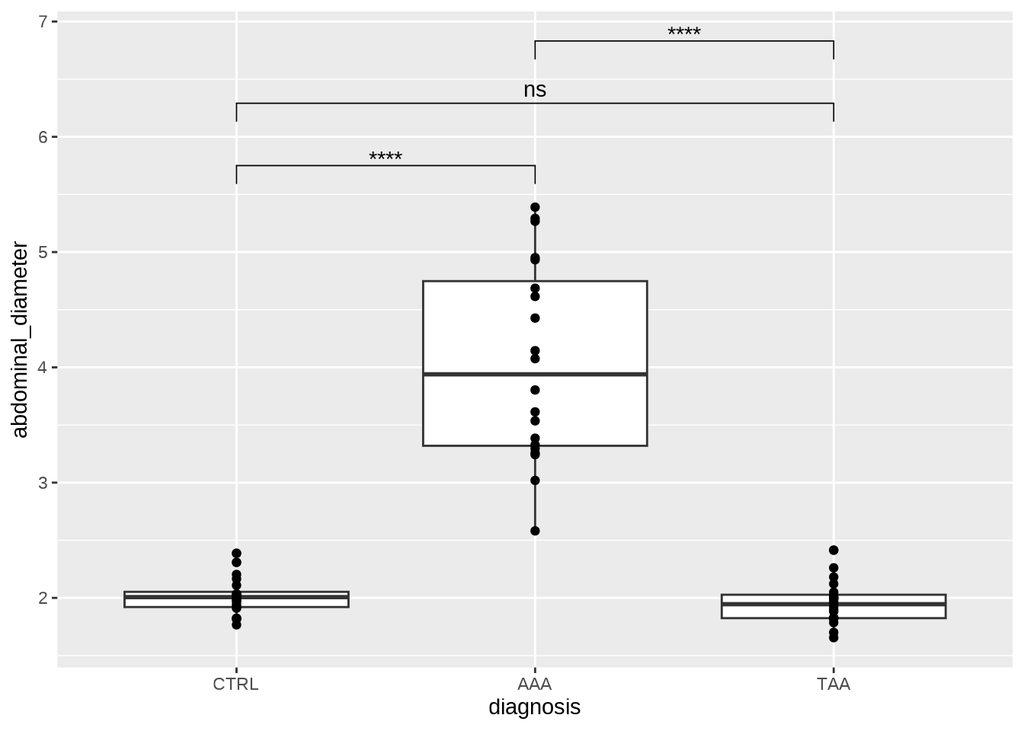

```r
stats <- df_sub %>%
  mutate(diagnosis = fct_relevel(diagnosis, "CTRL")) %>%
  rstatix::t_test(abdominal_diameter ~ diagnosis) %>%
  add_xy_position()


df_sub %>%
  mutate(diagnosis = fct_relevel(diagnosis, "CTRL")) %>%
  ggplot(aes(diagnosis, abdominal_diameter))+
  geom_boxplot()+
  geom_point()+
  ggpubr::stat_pvalue_manual(stats)
```

# Tasks

## Easy

E1: Subset the dataset to include only contain 3 observations per diagnosis. Create a box plot of abdominal aortic diameter. Repeat the sub-setting and the plotting. Is the plot changing?

E2: Repeat this with 10 observations per diagnosis. How stable is the re-sampling then?

E3: Lets stick with the 10 observations per observations. Create a boxplot again. Add points on top of it.

E4: What is the difference between `fill` and `color` for geom_boxplot? Try it out by adding some color to your boxplots.

E5: Create a scatter plot using BMI and abdominal aortic diameter. Do you think there is connection?

E6: Reuse the code for the scatter plot. Set the alpha of the points to 0.5 by using `geom_point(alpha = 0.5)`. What happens? How does the plot change when you change the value?

E7: Use the same process as above to try some values for the shape of `geom_point()`. The vlaues range from 0 to 25. Which one is a square with a cross in it?

E8: Using `aes()`, set the size of the points to age. What does the plot look like?

E9: Try setting the shape of the points by age. What is going wrong?

E10: Filter the original data set to patients with a BMI larger than 20. How many patients remain per diagnosis? Plot a bar chart to visualise it.

## Medium

M1: Create a box plot of abdominal aortic diameter. Reorder the X axis to have the CTRL diagnosis be the reference level

M2: Recreate the scatter plot from above. Color the points by diagnosis.

M3: Adjust the color code to something of your liking.

M4: Use geom_histogram() to visualise the distribution of abdominal diameter. Facet using the diagnosis.

M5: Sample your data to 10 observations per diagnosis. Use `stat_summary()` to generate a bar chart of thoracic diameter by diagnosis. Add error bars and individual observations.

M6: Building on the previous task, improve the looks of the previous plot like you would for an important presentation. Adjust Axis labels, fix the order on the x axis, give the plot a title. Color the bars by diagnosis. Try to make it as pleasing as possible (in your eyes).

M7: Sample your data to 3 observations per diagnosis. Test the difference in thoracic diameter between the diagnoses. Is the difference significant? Repeat the sampling and test again. Increase the number of observations per diagnosis to 5 and 10. How do the p-values change?

## Hard

H1: What happens when you run the following code?

```r
df <- read_tsv(here("data", "aneurysm_survey", "example_data.txt"))
df_plot <- df %>%
  group_by(diagnosis, hypertension) %>%
  slice_sample(n = 5) %>%
  ungroup() %>%
  mutate(hypertension = ifelse(hypertension, "present", "normal bp"))

df_plot  %>%
  ggplot(aes(hypertension, thoracic_diameter, color = diagnosis))+
  geom_boxplot()
```

H2: Try adding points to the plot using `geom_point()`. What happens? Can you fix their position? Hint: look at the `position` argument of `geom_point()`.

H3: Using what we learned last session, build an expression plot of *IL6* using the airway data. Best use `geom_boxplot()` and `geom_point()`.

H4: Can you add the significance to the plot?